# Part II - Effects Of Bike Share On User's Race Duration And Distance travel

## by Solomon Muoghara

## Investigation Overview

In this in investigation, i want to look at the effect bike share in the race of the particular data set have on both the distance traveled and the duration of the travel by different user types.

## Dataset Overview

This data set includes information about individual rides made in a bike-sharing system covering the greater San Francisco Bay area. There are 183412 listed bike rides and 16 features of which 9 variables are numeric; integers and floats, and 7 are Objects/Strings values. Of which i expect the following variables; duration_sec, start_station_latitude, start_station_longitude, end_station_latitude, end_station_longitude, user_type, share_bike_for_all_trip will be instrumental for my analysis findings.

## Distribution of Time Duration

[figure not shown]

## Distribution of Race Distance

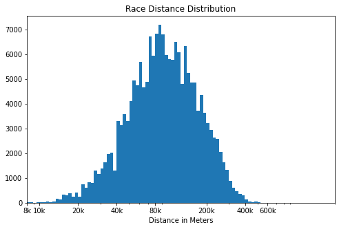

## User Type and Bike Share against Time Duration

The visualization plots three variables against each other, bike_share..., user_type and duration_min. Here, it also shows user_type = Customer have no value under bike_share...= Yes, which means no customer shared their bike but it does have a higher value under bike_share.. = No, which means that more user_type = Customer who didn't share their bike for all trip spend more time on the road getting to their end points than both subscribers who share and didn't share.

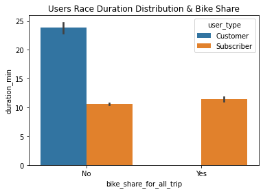

## User Type and Bike Share against Race Distance

The visualization plots three variables against each other, bike_share..., race_distance and user_type. Again, no user_type = customer value on bike_share... = Yes and also customer who didn't share their bike travelling longer distance than both subscribers who share their bike and those who didn't.

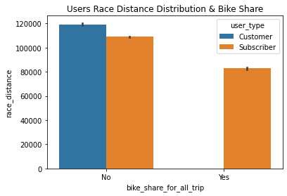